# 3.7 Beyond the standard full-sample pairwise sequence comparison

Alternative options to compare sequences

# Dissimilarity from a theoretical (ideal-typical) sequence

Depending on theoretical expectations of what a specific process should look like, we might want to consider different possible empirical realizations. To this purpose, we can imputing a reference sequence that reflects theoretical expectations about the appearance of specific states and their timing.

```r
theo.sps<-as.matrix("(S,5)-(MAR,2)-(MARc1,3)-(MARc2+,12)")
```

The object, however, is in SPS format:

```
     [,1]
[1,] "(S,5)-(MAR,2)-(MARc1,3)-(MARc2+,12)"
```

We need to transfor it in STS format:

```r
theo.sts <- seqformat(theo.sps, from = "SPS", to = "STS")
```

and therefore obtain:

```
    [1] [2] [3] [4] [5] [6]   [7]   [8]     [9]     [10]    [11]
[1] "S" "S" "S" "S" "S" "MAR" "MAR" "MARc1" "MARc1" "MARc1" "MARc2+"
    [12]     [13]     [14]     [15]     [16]     [17]     [18]
[1] "MARc2+" "MARc2+" "MARc2+" "MARc2+" "MARc2+" "MARc2+" "MARc2+"
    [19]     [20]     [21]     [22]
[1] "MARc2+" "MARc2+" "MARc2+" "MARc2+"
```

This string is not a sequence object yet, so that we define it as a sequence with the usual procedure:

```r
theo.seq<-seqdef(theo.sts,
                 states = shortlab.partner.child,
                 alphabet = shortlab.partner.child,
                 xtstep = 1)
```

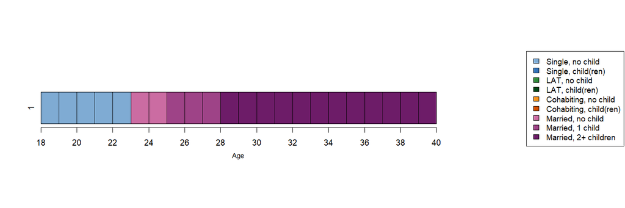

Finally, we can compute the dissimilarity matrix that this time includes the dissimilarity between the reference sequence `theo.seq` and all sequences in the dataset. The option `refseq` can be specified by indicating the name of the sequence used as a reference (as in the following example): the `TraMineR` documentation of the `seqdist` functin presents alternative specifications that might be useful depending on the research question.

```r
dist.theo<-seqdist(partner.child.year.seq.now, method = "OM", indel = 1, sm = "CONSTANT", refseq = theo.seq)
```

Let us consider for illustrative purposes the dissimilarity between the theoretical sequence and the (usual) three example sequences:

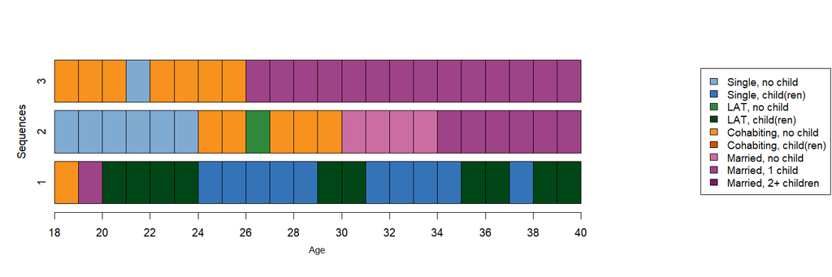

The dissimilarity between these three sequences and the theoretical sequence is, respectively:

| Sequence | Dissimilarity to reference seq. |
| --- | --- |
| 1 | 42 |
| 2 | 24 |
| 3 | 36 |

# Dissimilarity from the most frequent sequence

If we want to compare all sequences in the sample to the empirically most frequent one, we can identify it using the `seqtab` function, where the argument `idxs` allows for specifying the number of most frequent sequences to be estracted. Here, we consider only the first most frequent, and therefore we speficy it as follows:

```r
mostfreq.seq<-seqtab(partner.child.year.seq.now,
                     idxs = 1,
                     weighted = FALSE,
                     format = "SPS")
```

and obtain:

| Sequence | Frequency | Percentage |
| --- | --- | --- |
| S/22 | 14 | 0.75 |

that visually translate as follows:

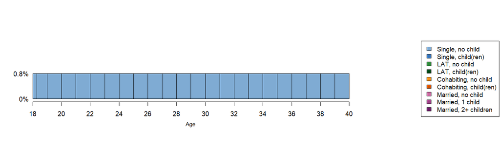

The percentage on the y-axis refers to the share of sequences identical to the one plotted. We can then compute the dissimilarity matrix specifying the `refseq` using `mostfreq.seq` as reference sequence

The dissimilarity between the three real sequences considered above and the most frequent sequence is, respectively:

| Sequence | Dissimilarity to reference seq. |
| --- | --- |
| 1 | 44 |
| 2 | 32 |
| 3 | 42 |

# Dissimilarity from the medoid

If we want to compare all sequences in the sample to the medoid, we first have to compute a standard pairwise dissimilarity matrix. For illustrative purposes, we set `indel = 1` and substitution costs `sm = CONSTANT` to generate the paiwise dissimilarity matrix `om.s2.i1`:

```r
om.s2.i1<-seqdist(partner.child.year.seq.now, method = "OM", indel = 1, sm = "CONSTANT")
```

We then identify the medois using the the `disscenter` function, where the argument `medoids.index` allows for specifying the option `first` to obtain the index of the first encountered most central sequence:

```r
medoid.seq <- disscenter(om.s2.i1, medoids.index = "first")
```

The medoid sequence is, in this case:

```r
print(partner.child.year.seq.now[medoid.seq, ], format = "SPS")
```

```
    Sequence
[1] (S,2)-(LAT,1)-(S,3)-(LAT,3)-(COH,2)-(MAR,2)-(MARc1,4)-(MARc2+,5)
```

that visually corresponds to:

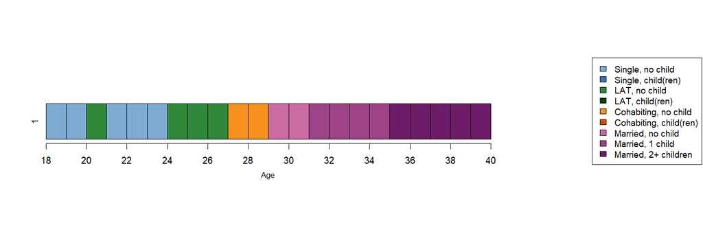

This plot can be obtained by specifying `partner.child.year.seq.now[medoid.seq,]` in the `seqiplot` function:

```r
png(file = "rChapter3-7-6_medoid_colors.png",
    width = 1500, height = 500, res = 120)

layout.fig1 <- layout(matrix(seq(1:2), 1, 2, byrow = TRUE),
                      widths = c(.7, .3))
layout.show(layout.fig1)

par(mar = c(8.2, 4, 9, 0) + 0.1, las = 1,
    mgp=c(2,1,-.5))
seqiplot(partner.child.year.seq.now[medoid.seq,], ylab = "",
         with.legend = "FALSE", border = TRUE, axes = FALSE,
         cpal = colspace2, main = "")
par(mgp=c(3,1,0.25))
axis(1, at=(seq(0,22, 2)), labels = seq(18,40, by = 2))
mtext(text = "Age", cex = .8,
      side = 1,#side 1 = bottom
      line = 2.5)

par(mar = c(5, 0, 4, 0) + 0.1)
seqlegend(partner.child.year.seq.now,
          cpal = colspace2, cex = .95, position = "right")

dev.off()
```

We can now compute the dissimilarity matrix specifying the `refseq` using `medoid.seq[1]` as reference sequence

```r
dist.medoid<-seqdist(partner.child.year.seq.now, method = "OM", indel = 1, sm = "CONSTANT",
                     refseq = medoid.seq[1])
```

The dissimilarity between the three real sequences considered above and the medoid is, respectively:

| Sequence | Dissimilarity to reference seq. |
| --- | --- |
| 1 | 40 |
| 2 | 16 |
| 3 | 30 |

If one wants to extract different medoids for different groups (for example by gender), it is possible to specify the `group` option accordingly:

```r
medoid.sex.seq <- disscenter(om.s2.i1, group=family$sex, medoids.index = "first")
```

The object `medoid.sex.seq` contains now two sequences, that is one medoid for the group of men (1) and one for the group of women (2) in the sample:

```
    Sequence
[1] (S,7)-(LAT,4)-(COH,3)-(MAR,2)-(MARc1,2)-(MARc2+,4)
[2] (S,3)-(LAT,3)-(COH,5)-(MAR,1)-(MARc1,3)-(MARc2+,7)
```

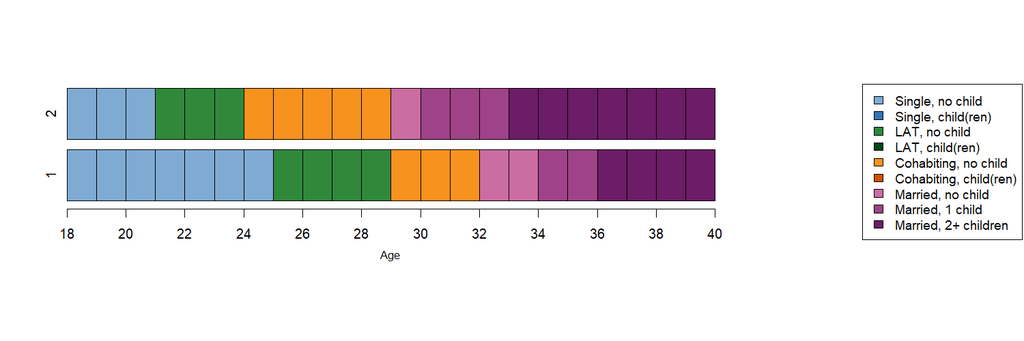